# Lab 6 Output

[output not shown]

Log  
Log - Log - August 15, 2018

GET  
FILE='C:\Users\Heather\OneDrive - Brock University\Masters\TA\BIOL3P96\2019\Lab 6\Birthweight.sav'.  
DATASET NAME DataSet15 WINDOW=FRONT.  
DATASET CLOSE DataSet1.  
* Chart Builder.  
GGRAPH  
/GRAPHDATASET NAME="graphdataset" VARIABLES=BirthWeight MISSING=LISTWISE REPORTMISSING=NO  
/GRAPHSPEC SOURCE=INLINE.  
BEGIN GPL  
SOURCE: s=userSource(id("graphdataset"))  
DATA: BirthWeight=col(source(s), name("BirthWeight"))  
GUIDE: axis(dim(1), label("Birth weight in g"))  
GUIDE: axis(dim(2), label("Frequency"))  
ELEMENT: interval(position(summary.count(bin.rect(BirthWeight))), shape.interior(shape.square))  
END GPL.

GGraph  
GGraph - Graph - August 15, 2018

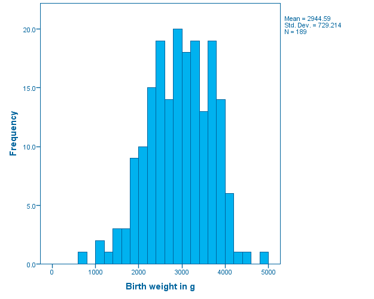

Log  
Log - Log - August 15, 2018

DESCRIPTIVES VARIABLES=BirthWeight  
/SAVE  
/STATISTICS=MEAN STDDEV MIN MAX.

Descriptives  
Descriptives - Descriptive Statistics - August 15, 2018

Descriptive StatisticsDescriptive Statistics, table, 1 levels of column headers and 1 levels of row headers, table with 6 columns and 4 rows

|  | N | Minimum | Maximum | Mean | Std. Deviation |
| --- | --- | --- | --- | --- | --- |
| Birth weight in g | 189 | 709 | 4990 | 2944.59 | 729.214 |
| Valid N (listwise) | 189 |  |  |  |  |

Log  
Log - Log - August 15, 2018

DESCRIPTIVES VARIABLES=BirthWeight ZBirthWeight  
/STATISTICS=MEAN STDDEV MIN MAX.

Descriptives  
Descriptives - Descriptive Statistics - August 15, 2018

Descriptive StatisticsDescriptive Statistics, table, 1 levels of column headers and 1 levels of row headers, table with 6 columns and 5 rows

|  | N | Minimum | Maximum | Mean | Std. Deviation |
| --- | --- | --- | --- | --- | --- |
| Birth weight in g | 189 | 709 | 4990 | 2944.59 | 729.214 |
| Zscore: Birth weight in g | 189 | -3.06575 | 2.80495 | .0000000 | 1.00000000 |
| Valid N (listwise) | 189 |  |  |  |  |

Log  
Log - Log - August 15, 2018

SUMMARIZE  
/TABLES=BirthWeight ZBirthWeight  
/FORMAT=VALIDLIST NOCASENUM TOTAL  
/TITLE='Case Summaries'  
/MISSING=VARIABLE  
/CELLS=COUNT.

Summarize  
Summarize - Case Processing Summary - August 15, 2018

Case Processing SummaryCase Processing Summary, table, 3 levels of column headers and 1 levels of row headers, table with 7 columns and 6 rows

|  | Cases |  |  |  |  |  |
| --- | --- | --- | --- | --- | --- | --- |
|  | Included |  | Excluded |  | Total |  |
|  | N | Percent | N | Percent | N | Percent |
| Birth weight in g | 189 | 100.0% | 0 | 0.0% | 189 | 100.0% |
| Zscore: Birth weight in g | 189 | 100.0% | 0 | 0.0% | 189 | 100.0% |

Summarize  
Summarize - Case Summaries - August 15, 2018

Case SummariesCase Summaries, table, 1 levels of column headers and 2 levels of row headers, table with 4 columns and 192 rows

|  |  | Birth weight in g | Zscore: Birth weight in g |
| --- | --- | --- | --- |
| 1 |  | 709 | -3.06575 |
| 2 |  | 1021 | -2.63789 |
| 3 |  | 1135 | -2.48156 |
| 4 |  | 1330 | -2.21415 |
| 5 |  | 1474 | -2.01667 |
| 6 |  | 1588 | -1.86034 |
| 7 |  | 1588 | -1.86034 |
| 8 |  | 1701 | -1.70538 |
| 9 |  | 1729 | -1.66698 |
| 10 |  | 1790 | -1.58333 |
| 11 |  | 1818 | -1.54493 |
| 12 |  | 1885 | -1.45305 |
| 13 |  | 1893 | -1.44208 |
| 14 |  | 1899 | -1.43385 |
| 15 |  | 1928 | -1.39409 |
| 16 |  | 1928 | -1.39409 |
| 17 |  | 1928 | -1.39409 |
| 18 |  | 1936 | -1.38312 |
| 19 |  | 1970 | -1.33649 |
| 20 |  | 2055 | -1.21993 |
| 21 |  | 2055 | -1.21993 |
| 22 |  | 2082 | -1.18290 |
| 23 |  | 2084 | -1.18016 |
| 24 |  | 2084 | -1.18016 |
| 25 |  | 2100 | -1.15822 |
| 26 |  | 2125 | -1.12393 |
| 27 |  | 2126 | -1.12256 |
| 28 |  | 2187 | -1.03891 |
| 29 |  | 2187 | -1.03891 |
| 30 |  | 2211 | -1.00600 |

[output cut: 160 more lines]

Log  
Log - Log - August 15, 2018

GET  
FILE='C:\Users\Heather\OneDrive - Brock University\Masters\TA\BIOL3P96\2019\Lab 6\Titanic.sav'.  
DATASET NAME DataSet16 WINDOW=FRONT.  
T-TEST  
/TESTVAL=18  
/MISSING=ANALYSIS  
/VARIABLES=Age  
/CRITERIA=CI(.95).

T-Test  
T-Test - Active Dataset - August 15, 2018

[DataSet16] C:\Users\Heather\OneDrive - Brock University\Masters\TA\BIOL3P96\2019\Lab 6\Titanic.sav

T-Test  
T-Test - One-Sample Statistics - August 15, 2018

One-Sample StatisticsOne-Sample Statistics, table, 1 levels of column headers and 1 levels of row headers, table with 5 columns and 3 rows

|  | N | Mean | Std. Deviation | Std. Error Mean |
| --- | --- | --- | --- | --- |
| Age | 633 | 31.19 | 14.748 | .586 |

T-Test  
T-Test - One-Sample Test - August 15, 2018

One-Sample TestOne-Sample Test, table, 3 levels of column headers and 1 levels of row headers, table with 7 columns and 5 rows

|  | Test Value = 18 |  |  |  |  |  |
| --- | --- | --- | --- | --- | --- | --- |
|  | t | df | Sig. (2-tailed) | Mean Difference | 95% Confidence Interval of the Difference |  |
|  |  |  |  |  | Lower | Upper |
| Age | 22.509 | 632 | .000 | 13.194 | 12.04 | 14.35 |

Log  
Log - Log - August 15, 2018

EXAMINE VARIABLES=Age  
/PLOT BOXPLOT STEMLEAF  
/COMPARE GROUPS  
/STATISTICS DESCRIPTIVES  
/CINTERVAL 95  
/MISSING LISTWISE  
/NOTOTAL.

Explore  
Explore - Case Processing Summary - August 15, 2018

Case Processing SummaryCase Processing Summary, table, 3 levels of column headers and 1 levels of row headers, table with 7 columns and 5 rows

|  | Cases |  |  |  |  |  |
| --- | --- | --- | --- | --- | --- | --- |
|  | Valid |  | Missing |  | Total |  |
|  | N | Percent | N | Percent | N | Percent |
| Age | 633 | 48.2% | 680 | 51.8% | 1313 | 100.0% |

Explore  
Explore - Descriptives - August 15, 2018

DescriptivesDescriptives, table, 1 levels of column headers and 3 levels of row headers, table with 5 columns and 15 rows

|  |  |  | Statistic | Std. Error |
| --- | --- | --- | --- | --- |
| Age | Mean |  | 31.19 | .586 |
|  | 95% Confidence Interval for Mean | Lower Bound | 30.04 |  |
|  |  | Upper Bound | 32.35 |  |
|  | 5% Trimmed Mean |  | 31.01 |  |
|  | Median |  | 30.00 |  |
|  | Variance |  | 217.490 |  |
|  | Std. Deviation |  | 14.748 |  |
|  | Minimum |  | 0 |  |
|  | Maximum |  | 71 |  |
|  | Range |  | 71 |  |
|  | Interquartile Range |  | 20 |  |
|  | Skewness |  | .303 | .097 |
|  | Kurtosis |  | -.222 | .194 |

Log  
Log - Log - August 15, 2018

CROSSTABS  
/TABLES=Survive BY PassengerClass  
/FORMAT=AVALUE TABLES  
/STATISTICS=CHISQ  
/CELLS=COUNT EXPECTED  
/COUNT ROUND CELL.

Crosstabs  
Crosstabs - Case Processing Summary - August 15, 2018

Case Processing SummaryCase Processing Summary, table, 3 levels of column headers and 1 levels of row headers, table with 7 columns and 5 rows

|  | Cases |  |  |  |  |  |
| --- | --- | --- | --- | --- | --- | --- |
|  | Valid |  | Missing |  | Total |  |
|  | N | Percent | N | Percent | N | Percent |
| Survive * PassengerClass | 1313 | 100.0% | 0 | 0.0% | 1313 | 100.0% |

Crosstabs  
Crosstabs - Survive * PassengerClass Crosstabulation - August 15, 2018

Survive * PassengerClass CrosstabulationSurvive * PassengerClass Crosstabulation, table, 2 levels of column headers and 3 levels of row headers, table with 7 columns and 9 rows

|  |  |  | PassengerClass |  |  | Total |  |
| --- | --- | --- | --- | --- | --- | --- | --- |
|  |  |  | 1st | 2nd | 3rd |  |  |
| Survive | Yes | Count | 193 | 119 | 137 |  | 449 |
|  |  | Expected Count | 110.1 | 95.8 | 243.1 | 449.0 |  |
|  | No | Count | 129 | 161 | 574 | 864 |  |
|  |  | Expected Count | 211.9 | 184.2 | 467.9 | 864.0 |  |
| Total |  | Count | 322 | 280 | 711 | 1313 |  |
|  |  | Expected Count | 322.0 | 280.0 | 711.0 | 1313.0 |  |

Crosstabs  
Crosstabs - Chi-Square Tests - August 15, 2018

Chi-Square TestsChi-Square Tests, table, 1 levels of column headers and 1 levels of row headers, table with 4 columns and 7 rows

|  | Value | df | Asymptotic Significance (2-sided) |
| --- | --- | --- | --- |
| Pearson Chi-Square | 173.807<sup>a</sup> | 2 | .000 |
| Likelihood Ratio | 174.425 | 2 | .000 |
| Linear-by-Linear Association | 172.882 | 1 | .000 |
| N of Valid Cases | 1313 |  |  |

a. 0 cells (0.0%) have expected count less than 5. The minimum expected count is 95.75.

Log  
Log - Log - August 15, 2018

CROSSTABS  
/TABLES=Survive BY Sex  
/FORMAT=AVALUE TABLES  
/STATISTICS=CHISQ  
/CELLS=COUNT EXPECTED  
/COUNT ROUND CELL.

Crosstabs  
Crosstabs - Case Processing Summary - August 15, 2018

Case Processing SummaryCase Processing Summary, table, 3 levels of column headers and 1 levels of row headers, table with 7 columns and 5 rows

|  | Cases |  |  |  |  |  |
| --- | --- | --- | --- | --- | --- | --- |
|  | Valid |  | Missing |  | Total |  |
|  | N | Percent | N | Percent | N | Percent |
| Survive * Sex | 1313 | 100.0% | 0 | 0.0% | 1313 | 100.0% |

Crosstabs  
Crosstabs - Survive * Sex Crosstabulation - August 15, 2018

Survive * Sex CrosstabulationSurvive * Sex Crosstabulation, table, 2 levels of column headers and 3 levels of row headers, table with 6 columns and 9 rows

|  |  |  | Sex |  | Total |  |
| --- | --- | --- | --- | --- | --- | --- |
|  |  |  | Female | Male |  |  |
| Survive | Yes | Count | 307 | 142 |  | 449 |
|  |  | Expected Count | 158.3 | 290.7 | 449.0 |  |
|  | No | Count | 156 | 708 | 864 |  |
|  |  | Expected Count | 304.7 | 559.3 | 864.0 |  |
| Total |  | Count | 463 | 850 | 1313 |  |
|  |  | Expected Count | 463.0 | 850.0 | 1313.0 |  |

Crosstabs  
Crosstabs - Chi-Square Tests - August 15, 2018

Chi-Square TestsChi-Square Tests, table, 1 levels of column headers and 1 levels of row headers, table with 6 columns and 10 rows

|  | Value | df | Asymptotic Significance (2-sided) | Exact Sig. (2-sided) | Exact Sig. (1-sided) |
| --- | --- | --- | --- | --- | --- |
| Pearson Chi-Square | 327.704<sup>a</sup> | 1 | .000 |  |  |
| Continuity Correction<sup>b</sup> | 325.504 | 1 | .000 |  |  |
| Likelihood Ratio | 328.037 | 1 | .000 |  |  |
| Fisher's Exact Test |  |  |  | .000 | .000 |
| Linear-by-Linear Association | 327.455 | 1 | .000 |  |  |
| N of Valid Cases | 1313 |  |  |  |  |

a. 0 cells (0.0%) have expected count less than 5. The minimum expected count is 158.33.  
b. Computed only for a 2x2 table

Log  
Log - Log - August 15, 2018

GET  
FILE='C:\Users\Heather\OneDrive - Brock University\Masters\TA\BIOL3P96\2019\Lab 6\Malaria mosquito.sav'.  
DATASET NAME DataSet17 WINDOW=FRONT.  
DESCRIPTIVES VARIABLES=MosquitosBefore  
/STATISTICS=MEAN.

Descriptives  
Descriptives - Active Dataset - August 15, 2018

[DataSet17] C:\Users\Heather\OneDrive - Brock University\Masters\TA\BIOL3P96\2019\Lab 6\Malaria mosquito.sav

Descriptives  
Descriptives - Descriptive Statistics - August 15, 2018

Descriptive StatisticsDescriptive Statistics, table, 1 levels of column headers and 1 levels of row headers, table with 3 columns and 4 rows

|  | N | Mean |
| --- | --- | --- |
| MosquitosBefore | 12 | .50208 |
| Valid N (listwise) | 12 |  |

Log  
Log - Log - August 15, 2018

T-TEST  
/TESTVAL=0.50208  
/MISSING=ANALYSIS  
/VARIABLES=MosquitosAfter  
/CRITERIA=CI(.95).

T-Test  
T-Test - One-Sample Statistics - August 15, 2018

One-Sample StatisticsOne-Sample Statistics, table, 1 levels of column headers and 1 levels of row headers, table with 5 columns and 3 rows

|  | N | Mean | Std. Deviation | Std. Error Mean |
| --- | --- | --- | --- | --- |
| MosquitosAfter | 12 | .22967 | .163942 | .047326 |

T-Test  
T-Test - One-Sample Test - August 15, 2018

One-Sample TestOne-Sample Test, table, 3 levels of column headers and 1 levels of row headers, table with 7 columns and 5 rows

|  | Test Value = 0.50208 |  |  |  |  |  |
| --- | --- | --- | --- | --- | --- | --- |
|  | t | df | Sig. (2-tailed) | Mean Difference | 95% Confidence Interval of the Difference |  |
|  |  |  |  |  | Lower | Upper |
| MosquitosAfter | -5.756 | 11 | .000 | -.272413 | -.37658 | -.16825 |

Log  
Log - Log - August 15, 2018

DATASET ACTIVATE DataSet19.  
COMPUTE ratio=bloodLeadBefore / bloodLeadAfter.  
EXECUTE.  
>Warning # 511  
>A division by zero has been attempted on the indicated command. The result  
>has been set to the system-missing value.  
>Command line: 324 Current case: 22 Current splitfile group: 1  
EXAMINE VARIABLES=ratio  
/PLOT BOXPLOT  
/COMPARE GROUPS  
/STATISTICS DESCRIPTIVES  
/CINTERVAL 95  
/MISSING LISTWISE  
/NOTOTAL.

Explore  
Explore - Active Dataset - August 15, 2018

[DataSet19] C:\Users\Heather\OneDrive - Brock University\Masters\TA\BIOL3P96\2019\Lab 6\Hurricanes blood lead.sav

Explore  
Explore - Case Processing Summary - August 15, 2018

Case Processing SummaryCase Processing Summary, table, 3 levels of column headers and 1 levels of row headers, table with 7 columns and 5 rows

|  | Cases |  |  |  |  |  |
| --- | --- | --- | --- | --- | --- | --- |
|  | Valid |  | Missing |  | Total |  |
|  | N | Percent | N | Percent | N | Percent |
| ratio | 45 | 97.8% | 1 | 2.2% | 46 | 100.0% |

Explore  
Explore - Descriptives - August 15, 2018

DescriptivesDescriptives, table, 1 levels of column headers and 3 levels of row headers, table with 5 columns and 15 rows

|  |  |  | Statistic | Std. Error |
| --- | --- | --- | --- | --- |
| ratio | Mean |  | 1.60873 | .088912 |
|  | 95% Confidence Interval for Mean | Lower Bound | 1.42954 |  |
|  |  | Upper Bound | 1.78792 |  |
|  | 5% Trimmed Mean |  | 1.54956 |  |
|  | Median |  | 1.55556 |  |
|  | Variance |  | .356 |  |
|  | Std. Deviation |  | .596438 |  |
|  | Minimum |  | .862 |  |
|  | Maximum |  | 3.846 |  |
|  | Range |  | 2.984 |  |
|  | Interquartile Range |  | .647 |  |
|  | Skewness |  | 1.657 | .354 |
|  | Kurtosis |  | 3.834 | .695 |

Log  
Log - Log - August 15, 2018

T-TEST  
/TESTVAL=1  
/MISSING=ANALYSIS  
/VARIABLES=ratio  
/CRITERIA=CI(.95).

T-Test  
T-Test - One-Sample Statistics - August 15, 2018

One-Sample StatisticsOne-Sample Statistics, table, 1 levels of column headers and 1 levels of row headers, table with 5 columns and 3 rows

|  | N | Mean | Std. Deviation | Std. Error Mean |
| --- | --- | --- | --- | --- |
| ratio | 45 | 1.60873 | .596438 | .088912 |

T-Test  
T-Test - One-Sample Test - August 15, 2018

One-Sample TestOne-Sample Test, table, 3 levels of column headers and 1 levels of row headers, table with 7 columns and 5 rows

|  | Test Value = 1 |  |  |  |  |  |
| --- | --- | --- | --- | --- | --- | --- |
|  | t | df | Sig. (2-tailed) | Mean Difference | 95% Confidence Interval of the Difference |  |
|  |  |  |  |  | Lower | Upper |
| ratio | 6.846 | 44 | .000 | .608729 | .42954 | .78792 |

Log  
Log - Log - August 15, 2018

DATASET ACTIVATE DataSet15.  
T-TEST  
/TESTVAL=3364  
/MISSING=ANALYSIS  
/VARIABLES=BirthWeight  
/CRITERIA=CI(.95).

T-Test  
T-Test - Active Dataset - August 15, 2018

[DataSet15] C:\Users\Heather\OneDrive - Brock University\Masters\TA\BIOL3P96\2019\Lab 6\Birthweight.sav

T-Test  
T-Test - One-Sample Statistics - August 15, 2018

One-Sample StatisticsOne-Sample Statistics, table, 1 levels of column headers and 1 levels of row headers, table with 5 columns and 3 rows

|  | N | Mean | Std. Deviation | Std. Error Mean |
| --- | --- | --- | --- | --- |
| Birth weight in g | 189 | 2944.59 | 729.214 | 53.043 |

T-Test  
T-Test - One-Sample Test - August 15, 2018

One-Sample TestOne-Sample Test, table, 3 levels of column headers and 1 levels of row headers, table with 7 columns and 5 rows

|  | Test Value = 3364 |  |  |  |  |  |
| --- | --- | --- | --- | --- | --- | --- |
|  | t | df | Sig. (2-tailed) | Mean Difference | 95% Confidence Interval of the Difference |  |
|  |  |  |  |  | Lower | Upper |
| Birth weight in g | -7.907 | 188 | .000 | -419.413 | -524.05 | -314.78 |

Log  
Log - Log - August 15, 2018

EXAMINE VARIABLES=BirthWeight BY Smoke  
/PLOT BOXPLOT  
/COMPARE GROUPS  
/STATISTICS DESCRIPTIVES  
/CINTERVAL 95  
/MISSING LISTWISE  
/NOTOTAL.

Smoking status during pregnancy  
Smoking status during pregnancy - Case Processing Summary - August 15, 2018

Case Processing SummaryCase Processing Summary, table, 3 levels of column headers and 2 levels of row headers, table with 8 columns and 6 rows

|  | Smoking status during pregnancy | Cases |  |  |  |  |  |
| --- | --- | --- | --- | --- | --- | --- | --- |
|  |  | Valid |  | Missing |  | Total |  |
|  |  | N | Percent | N | Percent | N | Percent |
| Birth weight in g | No | 115 | 100.0% | 0 | 0.0% | 115 | 100.0% |
|  | Yes | 74 | 100.0% | 0 | 0.0% | 74 | 100.0% |

Smoking status during pregnancy  
Smoking status during pregnancy - Descriptives - August 15, 2018

DescriptivesDescriptives, table, 1 levels of column headers and 4 levels of row headers, table with 6 columns and 28 rows

|  | Smoking status during pregnancy |  |  | Statistic | Std. Error |
| --- | --- | --- | --- | --- | --- |
| Birth weight in g | No | Mean |  | 3055.70 | 70.186 |
|  |  | 95% Confidence Interval for Mean | Lower Bound | 2916.66 |  |
|  |  |  | Upper Bound | 3194.73 |  |
|  |  | 5% Trimmed Mean |  | 3072.15 |  |
|  |  | Median |  | 3100.00 |  |
|  |  | Variance |  | 566491.968 |  |
|  |  | Std. Deviation |  | 752.657 |  |
|  |  | Minimum |  | 1021 |  |
|  |  | Maximum |  | 4990 |  |
|  |  | Range |  | 3969 |  |
|  |  | Interquartile Range |  | 1134 |  |
|  |  | Skewness |  | -.293 | .226 |
|  |  | Kurtosis |  | -.229 | .447 |
|  | Yes | Mean |  | 2771.92 | 76.681 |
|  |  | 95% Confidence Interval for Mean | Lower Bound | 2619.09 |  |
|  |  |  | Upper Bound | 2924.74 |  |
|  |  | 5% Trimmed Mean |  | 2784.60 |  |
|  |  | Median |  | 2775.50 |  |
|  |  | Variance |  | 435118.158 |  |
|  |  | Std. Deviation |  | 659.635 |  |
|  |  | Minimum |  | 709 |  |
|  |  | Maximum |  | 4238 |  |
|  |  | Range |  | 3529 |  |
|  |  | Interquartile Range |  | 907 |  |
|  |  | Skewness |  | -.291 | .279 |
|  |  | Kurtosis |  | .427 | .552 |

Log  
Log - Log - August 15, 2018

CROSSTABS  
/TABLES=LowWeight BY Uterine  
/FORMAT=AVALUE TABLES  
/STATISTICS=CHISQ RISK  
/CELLS=COUNT EXPECTED ROW  
/COUNT ROUND CELL.

Crosstabs  
Crosstabs - Case Processing Summary - August 15, 2018

Case Processing SummaryCase Processing Summary, table, 3 levels of column headers and 1 levels of row headers, table with 7 columns and 5 rows

|  | Cases |  |  |  |  |  |
| --- | --- | --- | --- | --- | --- | --- |
|  | Valid |  | Missing |  | Total |  |
|  | N | Percent | N | Percent | N | Percent |
| Birth weight less than 2.5 kg * Presence of uterine irritability | 189 | 100.0% | 0 | 0.0% | 189 | 100.0% |

Birth weight less than 2.5 kg * Presence of uterine irritability CrosstabulationBirth weight less than 2.5 kg * Presence of uterine irritability Crosstabulation, table, 2 levels of column headers and 3 levels of row headers, table with 6 columns and 12 rows

|  |  |  | Presence of uterine irritability |  | Total |  |
| --- | --- | --- | --- | --- | --- | --- |
|  |  |  | No | Yes |  |  |
| Birth weight less than 2.5 kg | No | Count | 116 | 14 |  | 130 |
|  |  | Expected Count | 110.7 | 19.3 | 130.0 |  |
|  |  | % within Birth weight less than 2.5 kg | 89.2% | 10.8% | 100.0% |  |
|  | Yes | Count | 45 | 14 | 59 |  |
|  |  | Expected Count | 50.3 | 8.7 | 59.0 |  |
|  |  | % within Birth weight less than 2.5 kg | 76.3% | 23.7% | 100.0% |  |
| Total |  | Count | 161 | 28 | 189 |  |
|  |  | Expected Count | 161.0 | 28.0 | 189.0 |  |
|  |  | % within Birth weight less than 2.5 kg | 85.2% | 14.8% | 100.0% |  |

Crosstabs  
Crosstabs - Chi-Square Tests - August 15, 2018

Chi-Square TestsChi-Square Tests, table, 1 levels of column headers and 1 levels of row headers, table with 6 columns and 10 rows

|  | Value | df | Asymptotic Significance (2-sided) | Exact Sig. (2-sided) | Exact Sig. (1-sided) |
| --- | --- | --- | --- | --- | --- |
| Pearson Chi-Square | 5.401<sup>a</sup> | 1 | .020 |  |  |
| Continuity Correction<sup>b</sup> | 4.423 | 1 | .035 |  |  |
| Likelihood Ratio | 5.076 | 1 | .024 |  |  |
| Fisher's Exact Test |  |  |  | .027 | .020 |
| Linear-by-Linear Association | 5.372 | 1 | .020 |  |  |
| N of Valid Cases | 189 |  |  |  |  |

a. 0 cells (0.0%) have expected count less than 5. The minimum expected count is 8.74.  
b. Computed only for a 2x2 table

Crosstabs  
Crosstabs - Risk Estimate - August 15, 2018

Risk EstimateRisk Estimate, table, 2 levels of column headers and 1 levels of row headers, table with 4 columns and 7 rows

|  | Value | 95% Confidence Interval |  |
| --- | --- | --- | --- |
|  |  | Lower | Upper |
| Odds Ratio for Birth weight less than 2.5 kg (No / Yes) | 2.578 | 1.139 | 5.834 |
| For cohort Presence of uterine irritability = No | 1.170 | 1.003 | 1.365 |
| For cohort Presence of uterine irritability = Yes | .454 | .231 | .890 |
| N of Valid Cases | 189 |  |  |

Log  
Log - Log - August 15, 2018

GET  
FILE='C:\Users\Heather\OneDrive - Brock University\Masters\TA\BIOL3P96\2019\Lab 6\Cats.sav'.  
DATASET NAME DataSet20 WINDOW=FRONT.  
DESCRIPTIVES VARIABLES=BodyWt  
/SAVE  
/STATISTICS=MEAN STDDEV MIN MAX.

Descriptives  
Descriptives - Active Dataset - August 15, 2018

[DataSet20] C:\Users\Heather\OneDrive - Brock University\Masters\TA\BIOL3P96\2019\Lab 6\Cats.sav

Descriptives  
Descriptives - Descriptive Statistics - August 15, 2018

Descriptive StatisticsDescriptive Statistics, table, 1 levels of column headers and 1 levels of row headers, table with 6 columns and 4 rows

|  | N | Minimum | Maximum | Mean | Std. Deviation |
| --- | --- | --- | --- | --- | --- |
| BodyWt | 137 | 6.30 | 15.40 | 10.3343 | 2.05618 |
| Valid N (listwise) | 137 |  |  |  |  |

Log  
Log - Log - August 15, 2018

DESCRIPTIVES VARIABLES=BodyWt ZBodyWt  
/STATISTICS=MEAN STDDEV MIN MAX.

Descriptives  
Descriptives - Descriptive Statistics - August 15, 2018

Descriptive StatisticsDescriptive Statistics, table, 1 levels of column headers and 1 levels of row headers, table with 6 columns and 5 rows

|  | N | Minimum | Maximum | Mean | Std. Deviation |
| --- | --- | --- | --- | --- | --- |
| BodyWt | 137 | 6.30 | 15.40 | 10.3343 | 2.05618 |
| Zscore(BodyWt) | 137 | -1.96204 | 2.46365 | .0000000 | 1.00000000 |
| Valid N (listwise) | 137 |  |  |  |  |

Log  
Log - Log - August 15, 2018

SUMMARIZE  
/TABLES=BodyWt ZBodyWt  
/FORMAT=VALIDLIST NOCASENUM TOTAL  
/TITLE='Case Summaries'  
/MISSING=VARIABLE  
/CELLS=COUNT.

Summarize  
Summarize - Case Processing Summary - August 15, 2018

Case Processing SummaryCase Processing Summary, table, 3 levels of column headers and 1 levels of row headers, table with 7 columns and 6 rows

|  | Cases |  |  |  |  |  |
| --- | --- | --- | --- | --- | --- | --- |
|  | Included |  | Excluded |  | Total |  |
|  | N | Percent | N | Percent | N | Percent |
| BodyWt | 137 | 100.0% | 0 | 0.0% | 137 | 100.0% |
| Zscore(BodyWt) | 137 | 100.0% | 0 | 0.0% | 137 | 100.0% |

Summarize  
Summarize - Case Summaries - August 15, 2018

Case SummariesCase Summaries, table, 1 levels of column headers and 2 levels of row headers, table with 4 columns and 140 rows

|  |  | BodyWt | Zscore(BodyWt) |
| --- | --- | --- | --- |
| 1 |  | 6.30 | -1.96204 |
| 2 |  | 6.50 | -1.86478 |
| 3 |  | 6.50 | -1.86478 |
| 4 |  | 7.00 | -1.62161 |
| 5 |  | 7.10 | -1.57297 |
| 6 |  | 7.20 | -1.52434 |
| 7 |  | 7.20 | -1.52434 |
| 8 |  | 7.30 | -1.47570 |
| 9 |  | 7.30 | -1.47570 |
| 10 |  | 7.30 | -1.47570 |
| 11 |  | 7.40 | -1.42707 |
| 12 |  | 7.60 | -1.32980 |
| 13 |  | 7.60 | -1.32980 |
| 14 |  | 7.70 | -1.28117 |
| 15 |  | 7.90 | -1.18390 |
| 16 |  | 7.90 | -1.18390 |
| 17 |  | 7.90 | -1.18390 |
| 18 |  | 7.90 | -1.18390 |
| 19 |  | 7.90 | -1.18390 |
| 20 |  | 8.00 | -1.13527 |
| 21 |  | 8.10 | -1.08663 |
| 22 |  | 8.20 | -1.03800 |
| 23 |  | 8.30 | -.98936 |
| 24 |  | 8.30 | -.98936 |
| 25 |  | 8.40 | -.94073 |
| 26 |  | 8.50 | -.89210 |
| 27 |  | 8.50 | -.89210 |
| 28 |  | 8.50 | -.89210 |
| 29 |  | 8.60 | -.84346 |
| 30 |  | 8.70 | -.79483 |

[output cut: 108 more lines]

Log  
Log - Log - August 15, 2018

GET  
FILE='C:\Users\Heather\OneDrive - Brock University\Masters\TA\BIOL3P96\2019\Lab 6\UScereal General Mills.sav'.

Log  
Log - Log - August 15, 2018

T-TEST  
/TESTVAL=149  
/MISSING=ANALYSIS  
/VARIABLES=Cals  
/CRITERIA=CI(.95).

T-Test  
T-Test - One-Sample Statistics - August 15, 2018

One-Sample StatisticsOne-Sample Statistics, table, 1 levels of column headers and 1 levels of row headers, table with 5 columns and 3 rows

|  | N | Mean | Std. Deviation | Std. Error Mean |
| --- | --- | --- | --- | --- |
| Cals | 22 | 137.7879 | 44.99660 | 9.59331 |

T-Test  
T-Test - One-Sample Test - August 15, 2018

One-Sample TestOne-Sample Test, table, 3 levels of column headers and 1 levels of row headers, table with 7 columns and 5 rows

|  | Test Value = 149 |  |  |  |  |  |
| --- | --- | --- | --- | --- | --- | --- |
|  | t | df | Sig. (2-tailed) | Mean Difference | 95% Confidence Interval of the Difference |  |
|  |  |  |  |  | Lower | Upper |
| Cals | -1.169 | 21 | .256 | -11.21212 | -31.1625 | 8.7383 |

Log  
Log - Log - August 15, 2018

T-TEST  
/TESTVAL=3.7  
/MISSING=ANALYSIS  
/VARIABLES=Protein  
/CRITERIA=CI(.95).

T-Test  
T-Test - One-Sample Statistics - August 15, 2018

One-Sample StatisticsOne-Sample Statistics, table, 1 levels of column headers and 1 levels of row headers, table with 5 columns and 3 rows

|  | N | Mean | Std. Deviation | Std. Error Mean |
| --- | --- | --- | --- | --- |
| Protein | 22 | 2.8848 | 1.62899 | .34730 |

T-Test  
T-Test - One-Sample Test - August 15, 2018

One-Sample TestOne-Sample Test, table, 3 levels of column headers and 1 levels of row headers, table with 7 columns and 5 rows

|  | Test Value = 3.7 |  |  |  |  |  |
| --- | --- | --- | --- | --- | --- | --- |
|  | t | df | Sig. (2-tailed) | Mean Difference | 95% Confidence Interval of the Difference |  |
|  |  |  |  |  | Lower | Upper |
| Protein | -2.347 | 21 | .029 | -.81515 | -1.5374 | -.0929 |

Log  
Log - Log - August 15, 2018

T-TEST  
/TESTVAL=1.4  
/MISSING=ANALYSIS  
/VARIABLES=Fat  
/CRITERIA=CI(.95).

T-Test  
T-Test - One-Sample Statistics - August 15, 2018

One-Sample StatisticsOne-Sample Statistics, table, 1 levels of column headers and 1 levels of row headers, table with 5 columns and 3 rows

|  | N | Mean | Std. Deviation | Std. Error Mean |
| --- | --- | --- | --- | --- |
| Fat | 22 | 1.7848 | 1.17576 | .25067 |

T-Test  
T-Test - One-Sample Test - August 15, 2018

One-Sample TestOne-Sample Test, table, 3 levels of column headers and 1 levels of row headers, table with 7 columns and 5 rows

|  | Test Value = 1.4 |  |  |  |  |  |
| --- | --- | --- | --- | --- | --- | --- |
|  | t | df | Sig. (2-tailed) | Mean Difference | 95% Confidence Interval of the Difference |  |
|  |  |  |  |  | Lower | Upper |
| Fat | 1.535 | 21 | .140 | .38485 | -.1365 | .9062 |

Log  
Log - Log - August 15, 2018

T-TEST  
/TESTVAL=3.8  
/MISSING=ANALYSIS  
/VARIABLES=Fibre  
/CRITERIA=CI(.95).

T-Test  
T-Test - One-Sample Statistics - August 15, 2018

One-Sample StatisticsOne-Sample Statistics, table, 1 levels of column headers and 1 levels of row headers, table with 5 columns and 3 rows

|  | N | Mean | Std. Deviation | Std. Error Mean |
| --- | --- | --- | --- | --- |
| Fibre | 22 | 1.6485 | 1.61503 | .34433 |

T-Test  
T-Test - One-Sample Test - August 15, 2018

One-Sample TestOne-Sample Test, table, 3 levels of column headers and 1 levels of row headers, table with 7 columns and 5 rows

|  | Test Value = 3.8 |  |  |  |  |  |
| --- | --- | --- | --- | --- | --- | --- |
|  | t | df | Sig. (2-tailed) | Mean Difference | 95% Confidence Interval of the Difference |  |
|  |  |  |  |  | Lower | Upper |
| Fibre | -6.248 | 21 | .000 | -2.15152 | -2.8676 | -1.4354 |

Log  
Log - Log - August 15, 2018

T-TEST  
/TESTVAL=19.9  
/MISSING=ANALYSIS  
/VARIABLES=Carbs  
/CRITERIA=CI(.95).

T-Test  
T-Test - One-Sample Statistics - August 15, 2018

One-Sample StatisticsOne-Sample Statistics, table, 1 levels of column headers and 1 levels of row headers, table with 5 columns and 3 rows

|  | N | Mean | Std. Deviation | Std. Error Mean |
| --- | --- | --- | --- | --- |
| Carbs | 22 | 17.6939 | 5.06189 | 1.07920 |

T-Test  
T-Test - One-Sample Test - August 15, 2018

One-Sample TestOne-Sample Test, table, 3 levels of column headers and 1 levels of row headers, table with 7 columns and 5 rows

|  | Test Value = 19.9 |  |  |  |  |  |
| --- | --- | --- | --- | --- | --- | --- |
|  | t | df | Sig. (2-tailed) | Mean Difference | 95% Confidence Interval of the Difference |  |
|  |  |  |  |  | Lower | Upper |
| Carbs | -2.044 | 21 | .054 | -2.20606 | -4.4504 | .0383 |

Log  
Log - Log - August 15, 2018

T-TEST  
/TESTVAL=10.1  
/MISSING=ANALYSIS  
/VARIABLES=Sugars  
/CRITERIA=CI(.95).

T-Test  
T-Test - One-Sample Statistics - August 15, 2018

One-Sample StatisticsOne-Sample Statistics, table, 1 levels of column headers and 1 levels of row headers, table with 5 columns and 3 rows

|  | N | Mean | Std. Deviation | Std. Error Mean |
| --- | --- | --- | --- | --- |
| Sugars | 22 | 10.0515 | 5.27259 | 1.12412 |

T-Test  
T-Test - One-Sample Test - August 15, 2018

One-Sample TestOne-Sample Test, table, 3 levels of column headers and 1 levels of row headers, table with 7 columns and 5 rows

|  | Test Value = 10.1 |  |  |  |  |  |
| --- | --- | --- | --- | --- | --- | --- |
|  | t | df | Sig. (2-tailed) | Mean Difference | 95% Confidence Interval of the Difference |  |
|  |  |  |  |  | Lower | Upper |
| Sugars | -.043 | 21 | .966 | -.04848 | -2.3862 | 2.2892 |

[output not shown]

[output not shown]

[output not shown]

[output not shown]

[output not shown]

[output not shown]